# Predicting Human Activities

Expedito Pinto de Paula Junior

11/1/2020

# 1.Synoposis

One thing that people regularly do is quantify how much of a particular activity they do, but they rarely quantify how well they do it. The goal of this project is use data from accelerometers on the belt, forearm, arm, and dumbell of 6 participants to predict the manner in which they did the exercise. This report describe:

1. How it was built the predict model;
2. How it was used cross validation;
3. What the expected out of sample error is; and
4. Why the choices was did.

For the validation model it was used the prediction model to predict 20 different test cases.

# 2. Data Processing.

## 2.1 Introduction

Using devices such as Jawbone Up, Nike FuelBand, and Fitbit it is now possible to collect a large amount of data about personal activity relatively inexpensively. These type of devices are part of the quantified self movement – a group of enthusiasts who take measurements about themselves regularly to improve their health, to find patterns in their behavior, or because they are tech geeks. One thing that people regularly do is quantify how much of a particular activity they do, but they rarely quantify how well they do it.

## 2.2 Data Loading

The following code load data for training and testing from the devices.

```r
library(caret)
library(knitr)
library(rpart)
```

```r
library(rpart.plot)
library(rattle)
library(randomForest)
library(e1071)
library(RColorBrewer)
library(corrplot)
library(gbm)
rm(list=ls())  # free up memory for the download of the data sets

# Create Data Directory if not exist
if (!file.exists("data")){
     dir.create("data")
}

# Download file from the web
fileURL_Training <- "https://d396qusza40orc.cloudfront.net/predmachlearn/pml-training.csv"
fileURL_Testing <- "https://d396qusza40orc.cloudfront.net/predmachlearn/pml-testing.csv"

download.file(fileURL_Training, destfile = "./data/plm-training.csv")
download.file(fileURL_Testing, destfile = "./data/plm-testing.csv")

# LoadFile
train <- read.csv("./data/plm-training.csv")
test <- read.csv("./data/plm-testing.csv")
```

## 2.2 Cleaning the input data.

Missing values could be affect criation model, based on this is necessary to remove variables that contains missing values.

- current dimension including missing values

```r
dim(train)
```

```
## [1] 19622   160
```

```r
dim(test)
```

```
## [1]  20 160
```

- cleaning data and remove invalid predictors

```r
# Clean Data and remove invalid predictors
trainData <- train[,colSums(is.na(train)) == 0]
testData <- test[,colSums(is.na(test)) == 0]

# Remove first seven variables
trainData <- trainData[,-c(1:7)]
testData <- testData[,-c(1:7)]

# Cleaning nearZeroVar
NZV <- nearZeroVar(trainData)
trainData <- trainData[,-NZV]
```

- cleaned dimension

```r
dim(trainData)
```

```
## [1] 19622    53
```

```r
dim(testData)
```

```
## [1] 20 53
```

## 2.3 Examining Variables

The follow variables are available in the dataset provided for training set:

```r
colnames(trainData)
```

```
##  [1] "roll_belt"            "pitch_belt"           "yaw_belt"
##  [4] "total_accel_belt"     "gyros_belt_x"         "gyros_belt_y"
##  [7] "gyros_belt_z"         "accel_belt_x"         "accel_belt_y"
## [10] "accel_belt_z"         "magnet_belt_x"        "magnet_belt_y"
## [13] "magnet_belt_z"        "roll_arm"             "pitch_arm"
## [16] "yaw_arm"              "total_accel_arm"      "gyros_arm_x"
## [19] "gyros_arm_y"          "gyros_arm_z"          "accel_arm_x"
## [22] "accel_arm_y"          "accel_arm_z"          "magnet_arm_x"
## [25] "magnet_arm_y"         "magnet_arm_z"         "roll_dumbbell"
## [28] "pitch_dumbbell"       "yaw_dumbbell"         "total_accel_dumbbell"
## [31] "gyros_dumbbell_x"     "gyros_dumbbell_y"     "gyros_dumbbell_z"
## [34] "accel_dumbbell_x"     "accel_dumbbell_y"     "accel_dumbbell_z"
## [37] "magnet_dumbbell_x"    "magnet_dumbbell_y"    "magnet_dumbbell_z"
## [40] "roll_forearm"         "pitch_forearm"        "yaw_forearm"
## [43] "total_accel_forearm"  "gyros_forearm_x"      "gyros_forearm_y"
## [46] "gyros_forearm_z"      "accel_forearm_x"      "accel_forearm_y"
## [49] "accel_forearm_z"      "magnet_forearm_x"     "magnet_forearm_y"
## [52] "magnet_forearm_z"     "classe"
```

```r
colnames(testData)
```

```
##  [1] "roll_belt"            "pitch_belt"           "yaw_belt"
##  [4] "total_accel_belt"     "gyros_belt_x"         "gyros_belt_y"
##  [7] "gyros_belt_z"         "accel_belt_x"         "accel_belt_y"
## [10] "accel_belt_z"         "magnet_belt_x"        "magnet_belt_y"
## [13] "magnet_belt_z"        "roll_arm"             "pitch_arm"
## [16] "yaw_arm"              "total_accel_arm"      "gyros_arm_x"
## [19] "gyros_arm_y"          "gyros_arm_z"          "accel_arm_x"
## [22] "accel_arm_y"          "accel_arm_z"          "magnet_arm_x"
## [25] "magnet_arm_y"         "magnet_arm_z"         "roll_dumbbell"
## [28] "pitch_dumbbell"       "yaw_dumbbell"         "total_accel_dumbbell"
## [31] "gyros_dumbbell_x"     "gyros_dumbbell_y"     "gyros_dumbbell_z"
## [34] "accel_dumbbell_x"     "accel_dumbbell_y"     "accel_dumbbell_z"
## [37] "magnet_dumbbell_x"    "magnet_dumbbell_y"    "magnet_dumbbell_z"
## [40] "roll_forearm"         "pitch_forearm"        "yaw_forearm"
## [43] "total_accel_forearm"  "gyros_forearm_x"      "gyros_forearm_y"
## [46] "gyros_forearm_z"      "accel_forearm_x"      "accel_forearm_y"
## [49] "accel_forearm_z"      "magnet_forearm_x"     "magnet_forearm_y"
## [52] "magnet_forearm_z"     "problem_id"
```

## 2.4 Correlation Variables

The correlation among variables is analyzed before proceeding to the predictive models in order to identify the most correlated variables in the dataset.

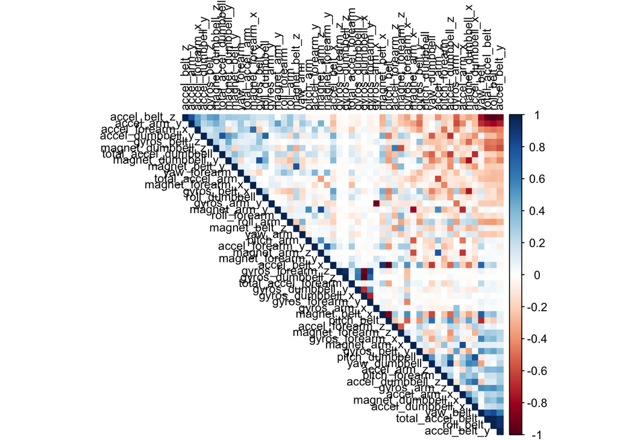

```r
# create correlation matrix and plot
cor_matrix <- cor(trainData[,-53])
corrplot(cor_matrix, order = "FPC", method="color", type="upper", tl.cex=0.8, tl.col=rgb(0,0,0))
```

```r
# get the highly correlated variables
highCorr <- findCorrelation(cor_matrix, cutoff = 0.85)

#show the highly correlated variables in training data set.
names(trainData)[highCorr]
```

```
## [1] "accel_belt_z"     "roll_belt"        "accel_belt_y"     "accel_belt_x"
## [5] "pitch_belt"       "gyros_dumbbell_x" "gyros_dumbbell_z" "gyros_arm_x"
```

# 3. Prediction Model

## 3.1 Building the Prediction Model.

```r
inTrain <- createDataPartition(y=trainData$classe, p=3/4, list = FALSE)

training <- trainData[inTrain,]
testing <- trainData[-inTrain,]

set.seed(1235)
```

### 3.1.1 Random Forest

Evaluating accuracy of Randon Forest Method.

```r
# 1.model fit
controlRF <- trainControl(method="cv", number=3, verboseIter=FALSE)
mod_rf <- train(classe ~ ., data=training, method="rf", trControl=controlRF)
mod_rf$finalModel
```

```
##
## Call:
##  randomForest(x = x, y = y, mtry = param$mtry)
##                Type of random forest: classification
##                      Number of trees: 500
## No. of variables tried at each split: 2
##
##         OOB estimate of  error rate: 0.65%
## Confusion matrix:
##      A    B    C    D    E  class.error
## A 4183    1    0    0    1 0.0004778973
## B   15 2828    5    0    0 0.0070224719
## C    0   18 2547    2    0 0.0077911959
## D    0    0   45 2364    3 0.0199004975
## E    0    0    0    5 2701 0.0018477458
```

```r
# 2. prediction
pred_rf <- predict(mod_rf, testing)
confM_rf <- confusionMatrix(table(pred_rf, testing$classe))

confM_rf
```

```
## Confusion Matrix and Statistics
##
##
## pred_rf    A    B    C    D    E
##       A 1393    6    0    0    0
##       B    2  943    9    0    0
##       C    0    0  845   12    0
##       D    0    0    1  792    6
##       E    0    0    0    0  895
##
## Overall Statistics
##
##                Accuracy : 0.9927
##                  95% CI : (0.9899, 0.9949)
##     No Information Rate : 0.2845
##     P-Value [Acc > NIR] : < 2.2e-16
##
##                   Kappa : 0.9907
##
##  Mcnemar's Test P-Value : NA
##
## Statistics by Class:
##
##                      Class: A Class: B Class: C Class: D Class: E
## Sensitivity            0.9986   0.9937   0.9883   0.9851   0.9933
## Specificity            0.9983   0.9972   0.9970   0.9983   1.0000
## Pos Pred Value         0.9957   0.9885   0.9860   0.9912   1.0000
## Neg Pred Value         0.9994   0.9985   0.9975   0.9971   0.9985
## Prevalence             0.2845   0.1935   0.1743   0.1639   0.1837
## Detection Rate         0.2841   0.1923   0.1723   0.1615   0.1825
## Detection Prevalence   0.2853   0.1945   0.1748   0.1629   0.1825
## Balanced Accuracy      0.9984   0.9954   0.9927   0.9917   0.9967
```

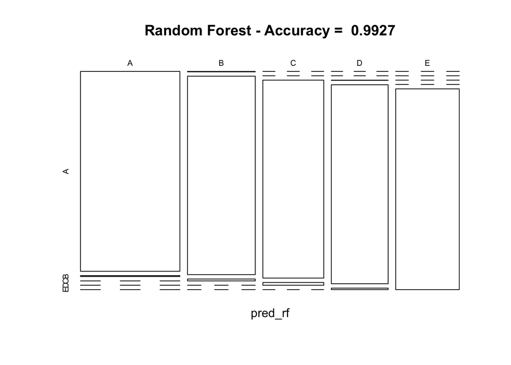

```r
# 3. ploting matrix result
plot(confM_rf$table, col=confM_rf$byClass, main = paste("Random Forest - Accuracy = ", round(confM_rf$overall['Accuracy'], 4)))
```

### 3.1.2 Decision Trees

Evaluating accuracy of Decision Trees Method.

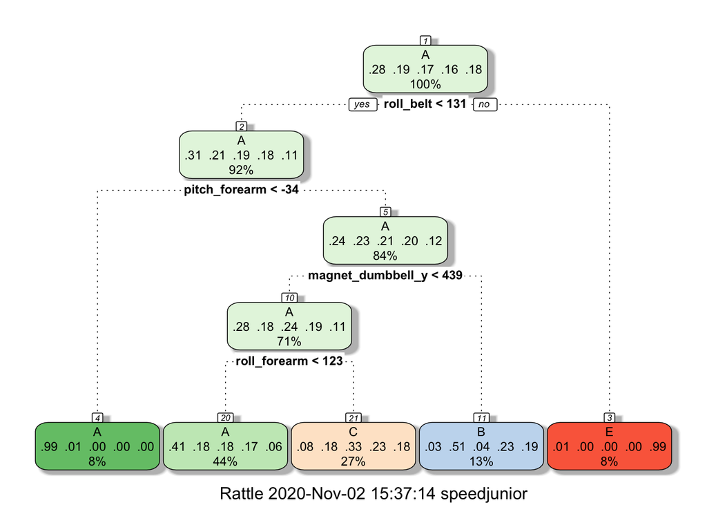

```r
# 1. model fit
ctrl_dt <- trainControl(method="repeatedcv", number = 10, repeats = 3)
mod_dt <- train(classe ~ ., data=training, method="rpart", trControl = ctrl_dt)
fancyRpartPlot(mod_dt$finalModel)
```

```r
# 2. prediction
pred_dt <- predict(mod_dt, testing)
confM_dt <- confusionMatrix(table(pred_dt,testing$classe))

confM_dt
```

```
## Confusion Matrix and Statistics
##
##
## pred_dt    A    B    C    D    E
##       A 1272  399  404  369  125
##       B   22  314   41  125  123
##       C   99  236  410  310  240
##       D    0    0    0    0    0
##       E    2    0    0    0  413
##
## Overall Statistics
##
##                Accuracy : 0.4912
##                  95% CI : (0.4771, 0.5053)
##     No Information Rate : 0.2845
##     P-Value [Acc > NIR] : < 2.2e-16
##
##                   Kappa : 0.3347
##
##  Mcnemar's Test P-Value : NA
##
## Statistics by Class:
##
##                      Class: A Class: B Class: C Class: D Class: E
## Sensitivity            0.9118  0.33087  0.47953   0.0000  0.45838
## Specificity            0.6304  0.92137  0.78143   1.0000  0.99950
## Pos Pred Value         0.4951  0.50240  0.31660      NaN  0.99518
## Neg Pred Value         0.9473  0.85160  0.87670   0.8361  0.89129
## Prevalence             0.2845  0.19352  0.17435   0.1639  0.18373
## Detection Rate         0.2594  0.06403  0.08361   0.0000  0.08422
## Detection Prevalence   0.5239  0.12745  0.26407   0.0000  0.08462
## Balanced Accuracy      0.7711  0.62612  0.63048   0.5000  0.72894
```

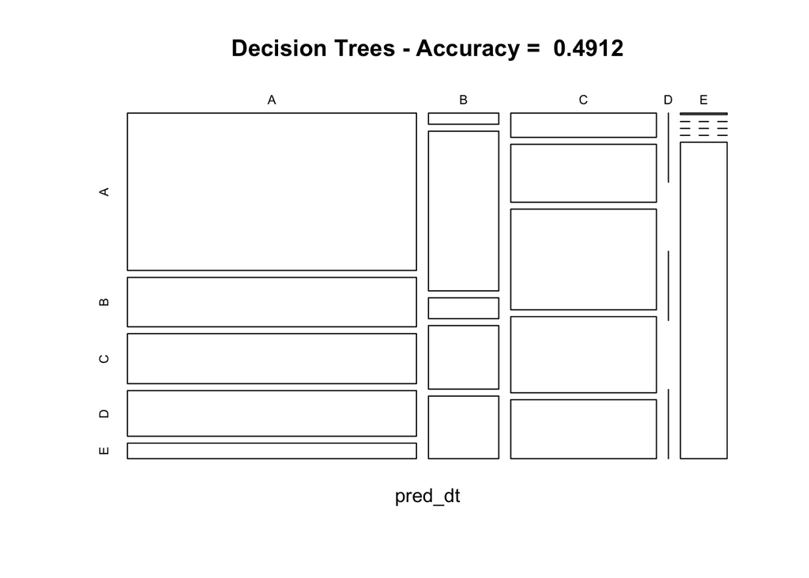

```r
# 3. ploting matrix result
plot(confM_dt$table, col=confM_dt$byClass, main = paste("Decision Trees - Accuracy = ", round(confM_dt$overall['Accuracy'], 4)))
```

### 3.1.3 GBM - Generalized Boosting Model

Evaluating accuracy of GBM.

```r
# 1. model fit
ctrl_gbm <- trainControl(method="repeatedcv", number = 5, repeats = 1)
mod_gbm <- train(classe ~ ., data=training, method = "gbm", trControl = ctrl_gbm, verbose=FALSE)
mod_gbm$finalModel
```

```
## A gradient boosted model with multinomial loss function.
## 150 iterations were performed.
## There were 52 predictors of which 51 had non-zero influence.
```

```r
# 2. prediction
pred_gbm <- predict(mod_gbm, newdata=testing)
confM_gbm <- confusionMatrix(table(pred_gbm,testing$classe))

confM_gbm
```

```
## Confusion Matrix and Statistics
##
##
## pred_gbm    A    B    C    D    E
##        A 1375   38    0    0    1
##        B   13  878   30    4   13
##        C    4   32  807   28   13
##        D    1    0   12  768   12
##        E    2    1    6    4  862
##
## Overall Statistics
##
##                Accuracy : 0.9564
##                  95% CI : (0.9503, 0.9619)
##     No Information Rate : 0.2845
##     P-Value [Acc > NIR] : < 2.2e-16
##
##                   Kappa : 0.9448
##
##  Mcnemar's Test P-Value : 2.251e-06
##
## Statistics by Class:
##
##                      Class: A Class: B Class: C Class: D Class: E
## Sensitivity            0.9857   0.9252   0.9439   0.9552   0.9567
## Specificity            0.9889   0.9848   0.9810   0.9939   0.9968
## Pos Pred Value         0.9724   0.9360   0.9129   0.9685   0.9851
## Neg Pred Value         0.9943   0.9821   0.9881   0.9912   0.9903
## Prevalence             0.2845   0.1935   0.1743   0.1639   0.1837
## Detection Rate         0.2804   0.1790   0.1646   0.1566   0.1758
## Detection Prevalence   0.2883   0.1913   0.1803   0.1617   0.1784
## Balanced Accuracy      0.9873   0.9550   0.9624   0.9746   0.9767
```

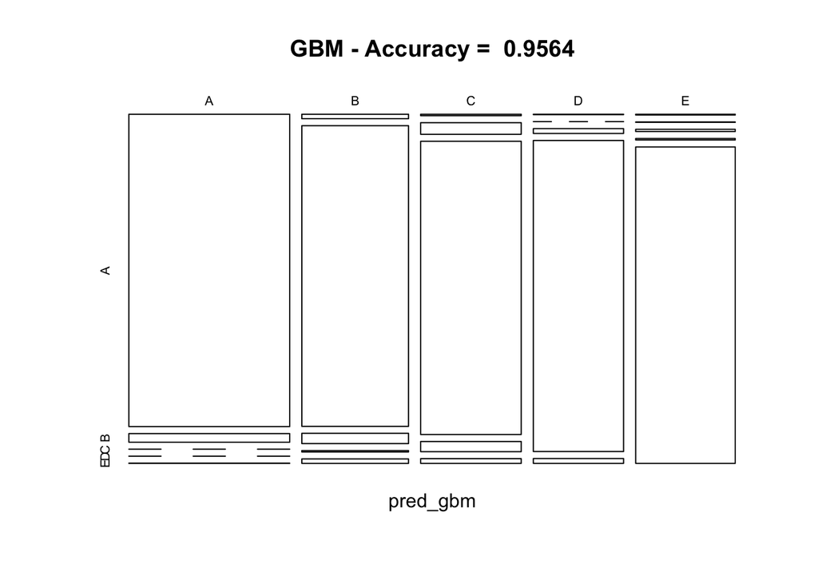

```r
# 3. ploting matrix result
plot(confM_gbm$table, col=confM_gbm$byClass, main = paste("GBM - Accuracy = ", round(confM_gbm$overall['Accuracy'], 4)))
```

## 3.2 Comparing Accurancy between model.

The accuracy of the 3 regression models are in table bellow:

| Method | Accuracy |
| --- | --- |
| Random Forest | 0.9927 |
| Decision Tree | 0.4912 |
| Generalized Boosting Model - GBM | 0.9564 |

According with the previous table the most accuracy method is **Random Forest**.

# 4. Predict the 20 quiz results

Using the most accuracy method before is possible to apply the model to predict the 20 quiz results based in the “validation” data provided in ‘*pml-testing.csv*’ file

```r
predictTest <- predict(mod_rf, newdata=testData)
predictTest
```

```
##  [1] B A B A A E D B A A B C B A E E A B B B
## Levels: A B C D E
```

# 5. Conclusions

1. Based in machine learning method is possible to build prediction models. The tidy dataset is the pre requirement for the best analysis as possible.
2. The cross validation is based in the creation multiples prediction models and select the best accuracy model generated.
3. Applying the most accuracy method is possible to achieve target results.